# Index

# Findings

### Supervised Machine Learning (Decision Tree Model)

Dataset Source: This data comes from the 2022 American Community Survey, and includes census tract-level data in the District of Columbia.

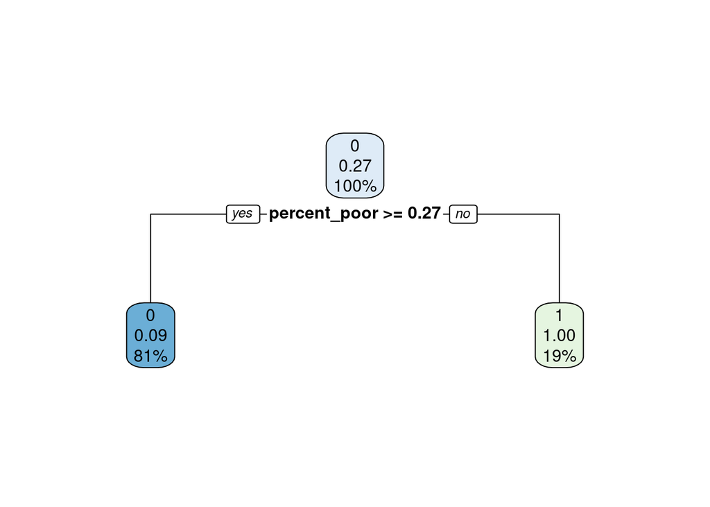

```r
#Set seed and split into training and test data
schools_nogeo <- read_csv("schools_nogeo (3).csv")
schools_nogeo <- schools_nogeo %>%
  select(poverty_status,
         SNAP_participation,
         rm_occupants,
         insurance_coverage,
         medicaid,
         income,
         percent_black,
         percent_poor,
         binary_ela_proficient)
schools_nogeo <- schools_nogeo %>%
  mutate(binary_ela_proficient = as.factor(binary_ela_proficient))
#Set seed and split into training and test data
set.seed(20220414)
schools_split <- initial_split(data = schools_nogeo, prop = 0.75)
schools_train <- training(x = schools_split)
schools_test <- testing(x = schools_split)


#Create Recipe
cart_schools_rec <-
  recipe(formula = binary_ela_proficient ~., data = schools_train) %>%
  step_corr(all_predictors())

#Create model
dectree_mod <-
  decision_tree() %>%
  set_engine(engine = "rpart") %>%
  set_mode(mod = "classification")

#Create a workflow
dectree_mod_wf <- workflow() %>%
  add_recipe(cart_schools_rec) %>%
  add_model(dectree_mod)

#Cross-fold validation
folds_resample <- vfold_cv(data = schools_train, v = 5)

#Fit the Model
dectree_fit <- dectree_mod_wf %>%
  parsnip::fit(data = schools_train)
rpart.plot::rpart.plot(x = dectree_fit$fit$fit$fit)
```

```r
#Add Resamples
dectree_fit_resamples <-
  dectree_mod_wf %>%
  fit_resamples(resamples = folds_resample)
```

### Evaluation of Supervised Machine Learning Model (Decision Tree Model)

```r
#Evaluate Model
collect_metrics(dectree_fit_resamples, summarize = TRUE)
```

```
# A tibble: 3 × 6
  .metric     .estimator   mean     n std_err .config
  <chr>       <chr>       <dbl> <int>   <dbl> <chr>
1 accuracy    binary     0.904      5  0.0230 Preprocessor1_Model1
2 brier_class binary     0.0877     5  0.0210 Preprocessor1_Model1
3 roc_auc     binary     0.832      5  0.0320 Preprocessor1_Model1
```

### Interpretation of Supervised Machine Learning Model (Decision Tree Model)

**Background:**

For this dataset, we created a binary variable called “proficiency” from the original variable that indicates the percentage of students in a school that scored a 4 or a 5 on the DC PARCC test. The variable created indicates if a given school had 50% or more students scoring above a 4 or 5 on the DC PARCC exam, the school is “proficient” in English language exam and if a school had less than 50% of students scoring above a 4 or 5 on the DC PARCC exam, the school is “not proficient” in the English language exam. The reason we chose 50% as the threshold was because the data itself showed that not many schools in the DC area had high percentages of students scoring above a 4 or 5 on the DC PARCC exam.

**Conclusions:**

The decision tree model created for our dataset indicates that 73% of schools (a majority) in the dataset are not proficient in English language exam. Put simply, 73% of schools had less than 50% of students scoring a 4 or 5 on the English language exam.Conversely, 27% of schools in the dataset are proficient in the English language exam (27% of schools had 50% or more students performing higher than a 4 or 5 on the English language exam). Additionally, the decision tree model selected the variable “Percent_poor” as a strong predictor for English language proficiency scores. Percent_poor indicates the percentage of students in a given school that are at or below the poverty line.

Overall, it was surprising that so many schools were categorized in the “not proficient” category. This model also explains that socioeconomic factors (being above or below the poverty line) do play a role in educational outcomes (proficiency in English language exams).

Looking at the error metrics, the accuracy is 90%. Accuracy is the the proportion of correctly classified observations (true positives and true negatives) out of the total number of observations. So 90% of observations were correctly classified by the model. In this case, 90% is a decent but not perfect accuracy measure, but is generally good at predicting true cases.